# Blood Pressure Project

ChiratchayaJanpechpanao

## Introduction

This project investigates how physiological and lifestyle factors relate to blood pressure. The dataset is simulated for practice purposes and includes variables such as age, weight, body surface area, pulse, stress, and duration of elevated blood pressure. All analysis was performed using R Studio.

Key Takeaways: Exploration and visualization help detect patterns in the data. Simulated datasets are useful for testing regression models.

The dataset contains 20 individuals, each representing one observation in a physiological or medical test. Every column describes a measurement related to the person’s body or their response during the test.

Variables:

Blood pressure (BP, in mm Hg) age (Age, in years <- factors) weight (Weight, in kg) body surface area (BSA, in sq m) duration of hypertension (DUR, in years) basal pulse (Pulse, in beats per minute <- factors) Stress index (Stress <-factors)

```r
library(esquisse)
```

```r
library(ggplot2)
library(leaps)
library(faraway)
library(stats)
```

```r
bloodData=read.table('blood.txt',header=T)
str(bloodData)
```

```
## 'data.frame':    20 obs. of  8 variables:
##  $ Pt    : int  1 2 3 4 5 6 7 8 9 10 ...
##  $ BP    : int  105 115 116 117 112 121 121 110 110 114 ...
##  $ Age   : int  47 49 49 50 51 48 49 47 49 48 ...
##  $ Weight: num  85.4 94.2 95.3 94.7 89.4 99.5 99.8 90.9 89.2 92.7 ...
##  $ BSA   : num  1.75 2.1 1.98 2.01 1.89 2.25 2.25 1.9 1.83 2.07 ...
##  $ Dur   : num  5.1 3.8 8.2 5.8 7 9.3 2.5 6.2 7.1 5.6 ...
##  $ Pulse : int  63 70 72 73 72 71 69 66 69 64 ...
##  $ Stress: int  33 14 10 99 95 10 42 8 62 35 ...
```

```r
bloodData$Pt <- NULL
bloodData
```

```
##     BP Age Weight  BSA  Dur Pulse Stress
## 1  105  47   85.4 1.75  5.1    63     33
## 2  115  49   94.2 2.10  3.8    70     14
## 3  116  49   95.3 1.98  8.2    72     10
## 4  117  50   94.7 2.01  5.8    73     99
## 5  112  51   89.4 1.89  7.0    72     95
## 6  121  48   99.5 2.25  9.3    71     10
## 7  121  49   99.8 2.25  2.5    69     42
## 8  110  47   90.9 1.90  6.2    66      8
## 9  110  49   89.2 1.83  7.1    69     62
## 10 114  48   92.7 2.07  5.6    64     35
## 11 114  47   94.4 2.07  5.3    74     90
## 12 115  49   94.1 1.98  5.6    71     21
## 13 114  50   91.6 2.05 10.2    68     47
## 14 106  45   87.1 1.92  5.6    67     80
## 15 125  52  101.3 2.19 10.0    76     98
## 16 114  46   94.5 1.98  7.4    69     95
## 17 106  46   87.0 1.87  3.6    62     18
## 18 113  46   94.5 1.90  4.3    70     12
## 19 110  48   90.5 1.88  9.0    71     99
## 20 122  56   95.7 2.09  7.0    75     99
```

#look at the response variable

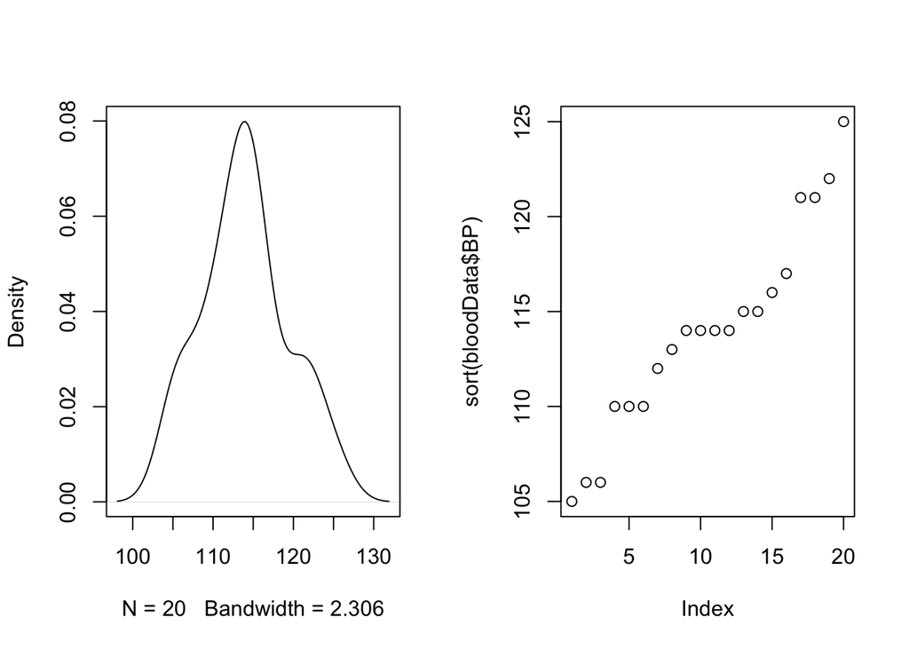

# lookt at outliers

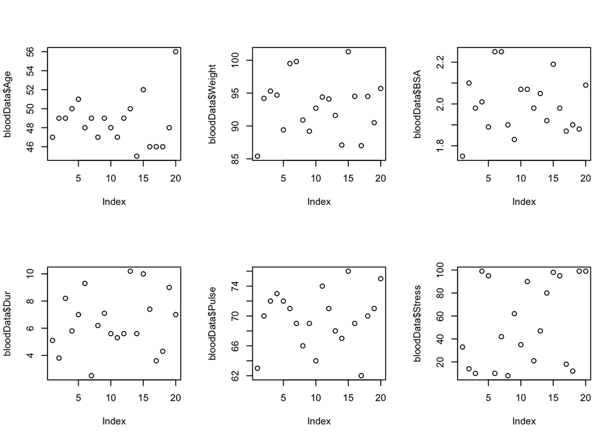

```r
par(mfrow=c(2,3))
plot(bloodData$Age)
plot(bloodData$Weight)
plot(bloodData$BSA)
plot(bloodData$Dur)
plot(bloodData$Pulse)
plot(bloodData$Stress)
```

# look at collinearity of the explnatory variables

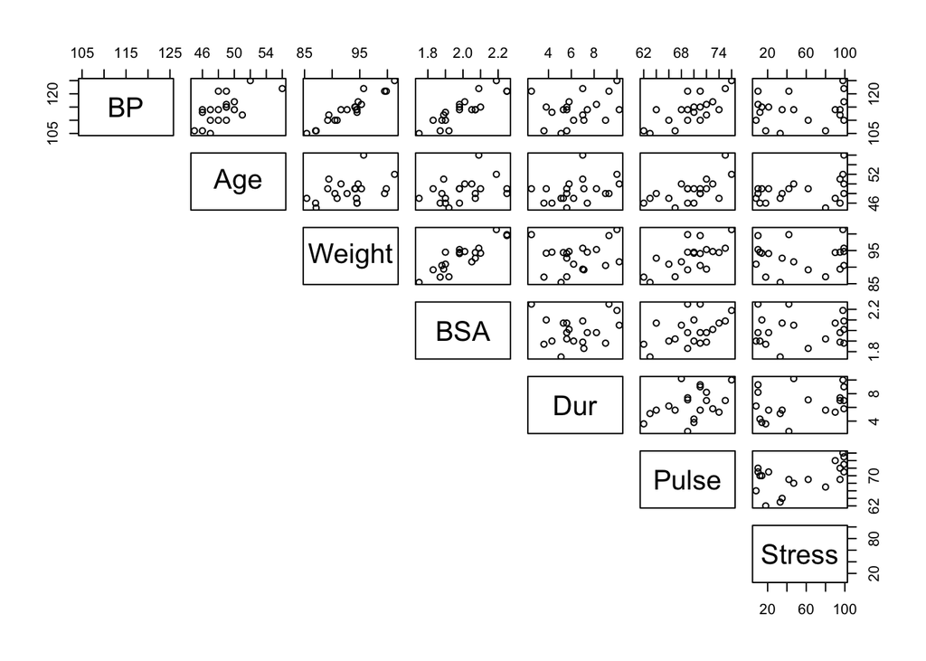

```r
pairs(bloodData[,1:7], pch = 1, cex = 0.9,lower.panel = NULL)
```

```r
cor(bloodData)
```

```
##               BP       Age     Weight        BSA       Dur     Pulse     Stress
## BP     1.0000000 0.6590930 0.95006765 0.86587887 0.2928336 0.7214132 0.16390139
## Age    0.6590930 1.0000000 0.40734926 0.37845460 0.3437921 0.6187643 0.36822369
## Weight 0.9500677 0.4073493 1.00000000 0.87530481 0.2006496 0.6593399 0.03435475
## BSA    0.8658789 0.3784546 0.87530481 1.00000000 0.1305400 0.4648188 0.01844634
## Dur    0.2928336 0.3437921 0.20064959 0.13054001 1.0000000 0.4015144 0.31163982
## Pulse  0.7214132 0.6187643 0.65933987 0.46481881 0.4015144 1.0000000 0.50631008
## Stress 0.1639014 0.3682237 0.03435475 0.01844634 0.3116398 0.5063101 1.00000000
```

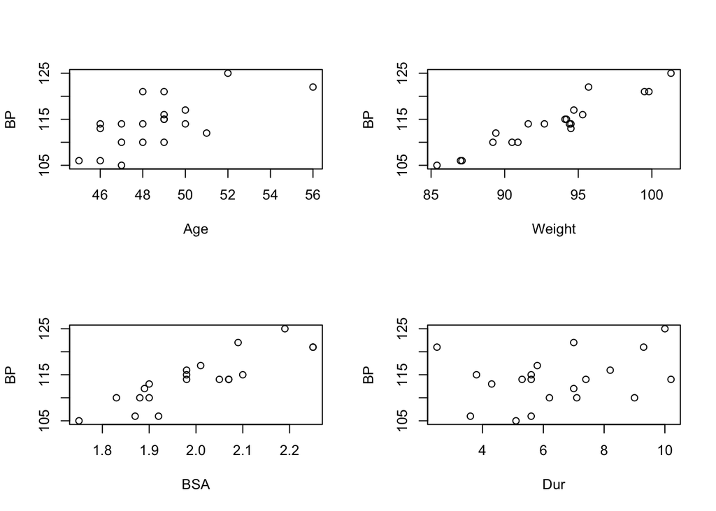

```r
par(mfrow = c(2,2))
#plotting all pairs
plot(BP ~ Age, data=bloodData)
plot(BP ~ Weight, data=bloodData)
plot(BP ~ BSA, data=bloodData)
plot(BP ~ Dur, data=bloodData)
```

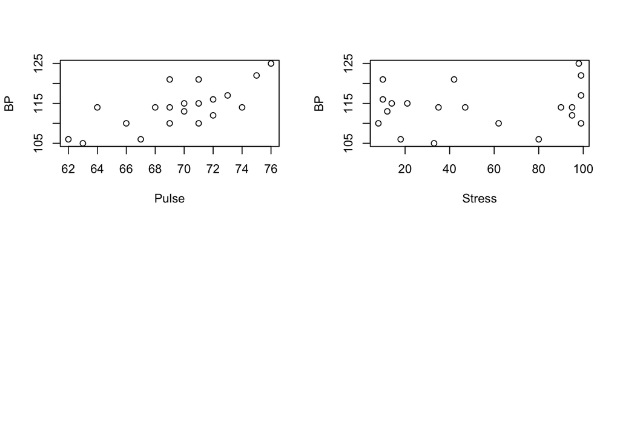

```r
plot(BP ~ Pulse, data=bloodData)
plot(BP ~ Stress, data=bloodData)
```

# Simple linear regression model - one predictor

Across the six simple linear models, Weight stands out as the strongest predictor of blood pressure. The BP–Weight model explains about 90 percent of the variation in blood pressure and shows a very strong, highly significant positive relationship.

BSA also performs well, with a solid positive effect and an R² around 0.75. Pulse and Age show moderate positive relationships with BP, both statistically significant but explaining less variation.

In contrast, Duration and Stress show no meaningful relationship with blood pressure. Their slopes are small, not significant, and the R² values are near zero.

Overall, the results suggest that body size variables, especially Weight, are the most useful single predictors of blood pressure in this dataset.

```r
mdl <- lm(BP ~ Age, data=bloodData)
mdl2 <- lm(BP ~ Weight, data=bloodData)
mdl3 <- lm(BP ~ BSA, data=bloodData)
mdl4 <- lm(BP ~ Dur, data=bloodData)    #no significant
mdl5 <- lm(BP ~ Pulse, data=bloodData)
mdl6 <- lm(BP ~ Stress, data=bloodData) #no significant

'check the models'
```

```
## [1] "check the models"
```

```r
summary(mdl)
```

```
##
## Call:
## lm(formula = BP ~ Age, data = bloodData)
##
## Residuals:
##     Min      1Q  Median      3Q     Max
## -6.7104 -2.9217  0.4276  2.3973  7.8586
##
## Coefficients:
##             Estimate Std. Error t value Pr(>|t|)
## (Intercept)  44.4545    18.7277   2.374  0.02894 *
## Age           1.4310     0.3849   3.718  0.00157 **
## ---
## Signif. codes:  0 '***' 0.001 '**' 0.01 '*' 0.05 '.' 0.1 ' ' 1
##
## Residual standard error: 4.195 on 18 degrees of freedom
## Multiple R-squared:  0.4344, Adjusted R-squared:  0.403
## F-statistic: 13.82 on 1 and 18 DF,  p-value: 0.001574
```

```r
summary(mdl2) #***
```

```
##
## Call:
## lm(formula = BP ~ Weight, data = bloodData)
##
## Residuals:
##     Min      1Q  Median      3Q     Max
## -2.6933 -0.9318 -0.4935  0.7703  4.8656
##
## Coefficients:
##             Estimate Std. Error t value Pr(>|t|)
## (Intercept)  2.20531    8.66333   0.255    0.802
## Weight       1.20093    0.09297  12.917 1.53e-10 ***
## ---
## Signif. codes:  0 '***' 0.001 '**' 0.01 '*' 0.05 '.' 0.1 ' ' 1
##
## Residual standard error: 1.74 on 18 degrees of freedom
## Multiple R-squared:  0.9026, Adjusted R-squared:  0.8972
## F-statistic: 166.9 on 1 and 18 DF,  p-value: 1.528e-10
```

```r
summary(mdl3) #***
```

```
##
## Call:
## lm(formula = BP ~ BSA, data = bloodData)
##
## Residuals:
##    Min     1Q Median     3Q    Max
## -5.314 -1.963 -0.197  1.934  4.831
##
## Coefficients:
##             Estimate Std. Error t value Pr(>|t|)
## (Intercept)   45.183      9.392   4.811  0.00014 ***
## BSA           34.443      4.690   7.343 8.11e-07 ***
## ---
## Signif. codes:  0 '***' 0.001 '**' 0.01 '*' 0.05 '.' 0.1 ' ' 1
##
## Residual standard error: 2.79 on 18 degrees of freedom
## Multiple R-squared:  0.7497, Adjusted R-squared:  0.7358
## F-statistic: 53.93 on 1 and 18 DF,  p-value: 8.114e-07
```

```r
summary(mdl4)
```

```
##
## Call:
## lm(formula = BP ~ Dur, data = bloodData)
##
## Residuals:
##     Min      1Q  Median      3Q     Max
## -8.0144 -3.9963  0.5968  3.0785  9.9124
##
## Coefficients:
##             Estimate Std. Error t value Pr(>|t|)
## (Intercept) 109.2350     3.8563  28.327   <2e-16 ***
## Dur           0.7411     0.5703   1.299     0.21
## ---
## Signif. codes:  0 '***' 0.001 '**' 0.01 '*' 0.05 '.' 0.1 ' ' 1
##
## Residual standard error: 5.333 on 18 degrees of freedom
## Multiple R-squared:  0.08575,    Adjusted R-squared:  0.03496
## F-statistic: 1.688 on 1 and 18 DF,  p-value: 0.2102
```

```r
summary(mdl5)
```

```
##
## Call:
## lm(formula = BP ~ Pulse, data = bloodData)
##
## Residuals:
##     Min      1Q  Median      3Q     Max
## -5.4418 -2.4978 -0.3672  1.8455  7.6179
##
## Coefficients:
##             Estimate Std. Error t value Pr(>|t|)
## (Intercept)   42.323     16.240   2.606 0.017871 *
## Pulse          1.030      0.233   4.420 0.000331 ***
## ---
## Signif. codes:  0 '***' 0.001 '**' 0.01 '*' 0.05 '.' 0.1 ' ' 1
##
## Residual standard error: 3.863 on 18 degrees of freedom
## Multiple R-squared:  0.5204, Adjusted R-squared:  0.4938
## F-statistic: 19.53 on 1 and 18 DF,  p-value: 0.0003307
```

```r
summary(mdl6)
```

```
##
## Call:
## lm(formula = BP ~ Stress, data = bloodData)
##
## Residuals:
##     Min      1Q  Median      3Q     Max
## -8.6394 -3.3014  0.0722  2.2181  9.9287
##
## Coefficients:
##              Estimate Std. Error t value Pr(>|t|)
## (Intercept) 112.71997    2.19345  51.389   <2e-16 ***
## Stress        0.02399    0.03404   0.705     0.49
## ---
## Signif. codes:  0 '***' 0.001 '**' 0.01 '*' 0.05 '.' 0.1 ' ' 1
##
## Residual standard error: 5.502 on 18 degrees of freedom
## Multiple R-squared:  0.02686,    Adjusted R-squared:  -0.0272
## F-statistic: 0.4969 on 1 and 18 DF,  p-value: 0.4899
```

# Find a model with a high adjusted R2

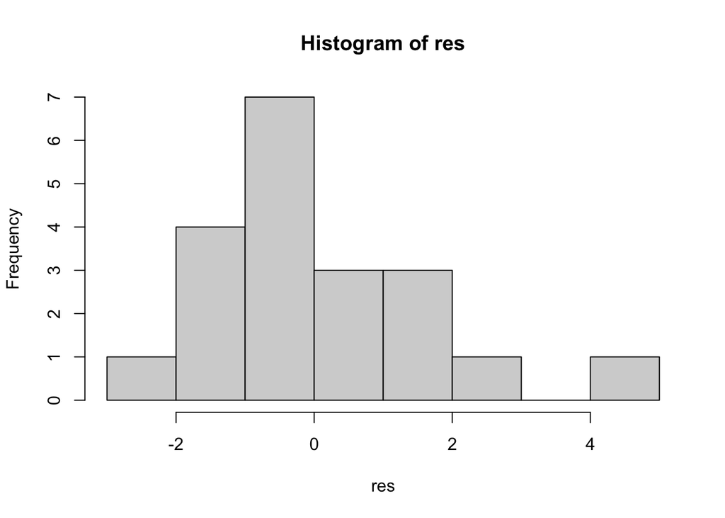

```r
# For mdl2
res <- resid(mdl2)
hist(res)
```

# produce residual vs. fitted plot

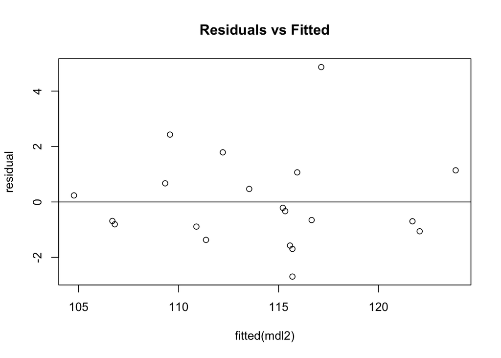

```r
#produce residual vs. fitted plot
plot(fitted(mdl2), res,  main = "Residuals vs Fitted" ,ylab="residual")
#add a horizontal line at 0
abline(0,0)
```

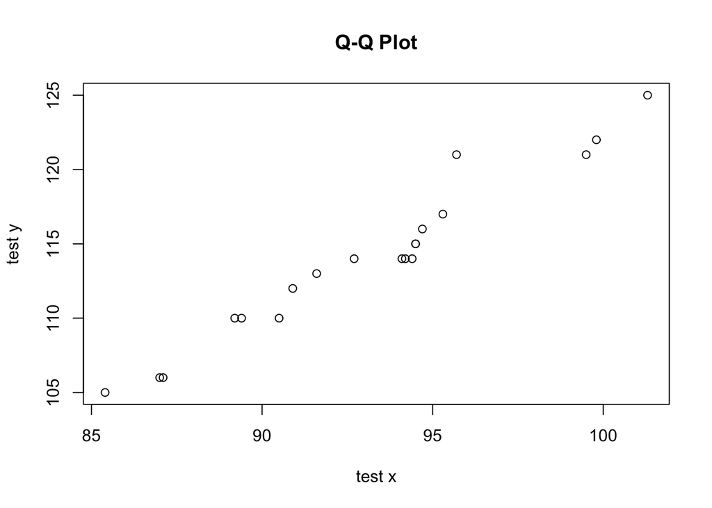

```r
qqplot(bloodData$Weight,bloodData$BP, xlab = "test x", ylab = "test y", main = "Q-Q Plot")
```

# Visualise the model together with data

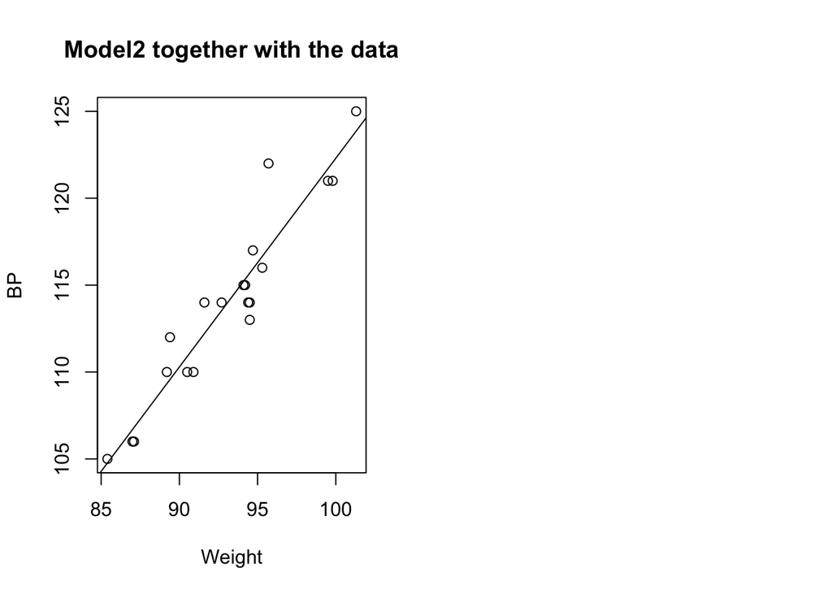

```r
# Visualise the model together with data
par(mfrow=c(1,2))
plot(BP ~ Weight, data = bloodData, main="Model2 together with the data")
abline(mdl2)
```

#Is the model statistically significant?

I analyzed six simple linear regression models to see how different variables predict blood pressure. Weight is by far the strongest predictor. Its model explains about 90 percent of the variation in BP and shows a very strong positive effect. BSA also has a strong positive relationship with BP, with an R² around 0.75. Age and Pulse show moderate positive effects, both significant but weaker.

In contrast, Duration and Stress do not meaningfully predict BP. Their slopes are small, not significant, and their R² values are close to zero.

Overall, body size measures, especially Weight, provide the best single-variable explanation of blood pressure in this dataset.

```r
summary(mdl) #**
```

```
##
## Call:
## lm(formula = BP ~ Age, data = bloodData)
##
## Residuals:
##     Min      1Q  Median      3Q     Max
## -6.7104 -2.9217  0.4276  2.3973  7.8586
##
## Coefficients:
##             Estimate Std. Error t value Pr(>|t|)
## (Intercept)  44.4545    18.7277   2.374  0.02894 *
## Age           1.4310     0.3849   3.718  0.00157 **
## ---
## Signif. codes:  0 '***' 0.001 '**' 0.01 '*' 0.05 '.' 0.1 ' ' 1
##
## Residual standard error: 4.195 on 18 degrees of freedom
## Multiple R-squared:  0.4344, Adjusted R-squared:  0.403
## F-statistic: 13.82 on 1 and 18 DF,  p-value: 0.001574
```

```r
summary(mdl2) #***
```

```
##
## Call:
## lm(formula = BP ~ Weight, data = bloodData)
##
## Residuals:
##     Min      1Q  Median      3Q     Max
## -2.6933 -0.9318 -0.4935  0.7703  4.8656
##
## Coefficients:
##             Estimate Std. Error t value Pr(>|t|)
## (Intercept)  2.20531    8.66333   0.255    0.802
## Weight       1.20093    0.09297  12.917 1.53e-10 ***
## ---
## Signif. codes:  0 '***' 0.001 '**' 0.01 '*' 0.05 '.' 0.1 ' ' 1
##
## Residual standard error: 1.74 on 18 degrees of freedom
## Multiple R-squared:  0.9026, Adjusted R-squared:  0.8972
## F-statistic: 166.9 on 1 and 18 DF,  p-value: 1.528e-10
```

```r
summary(mdl3) #***
```

```
##
## Call:
## lm(formula = BP ~ BSA, data = bloodData)
##
## Residuals:
##    Min     1Q Median     3Q    Max
## -5.314 -1.963 -0.197  1.934  4.831
##
## Coefficients:
##             Estimate Std. Error t value Pr(>|t|)
## (Intercept)   45.183      9.392   4.811  0.00014 ***
## BSA           34.443      4.690   7.343 8.11e-07 ***
## ---
## Signif. codes:  0 '***' 0.001 '**' 0.01 '*' 0.05 '.' 0.1 ' ' 1
##
## Residual standard error: 2.79 on 18 degrees of freedom
## Multiple R-squared:  0.7497, Adjusted R-squared:  0.7358
## F-statistic: 53.93 on 1 and 18 DF,  p-value: 8.114e-07
```

```r
summary(mdl4)
```

```
##
## Call:
## lm(formula = BP ~ Dur, data = bloodData)
##
## Residuals:
##     Min      1Q  Median      3Q     Max
## -8.0144 -3.9963  0.5968  3.0785  9.9124
##
## Coefficients:
##             Estimate Std. Error t value Pr(>|t|)
## (Intercept) 109.2350     3.8563  28.327   <2e-16 ***
## Dur           0.7411     0.5703   1.299     0.21
## ---
## Signif. codes:  0 '***' 0.001 '**' 0.01 '*' 0.05 '.' 0.1 ' ' 1
##
## Residual standard error: 5.333 on 18 degrees of freedom
## Multiple R-squared:  0.08575,    Adjusted R-squared:  0.03496
## F-statistic: 1.688 on 1 and 18 DF,  p-value: 0.2102
```

```r
summary(mdl5)
```

```
##
## Call:
## lm(formula = BP ~ Pulse, data = bloodData)
##
## Residuals:
##     Min      1Q  Median      3Q     Max
## -5.4418 -2.4978 -0.3672  1.8455  7.6179
##
## Coefficients:
##             Estimate Std. Error t value Pr(>|t|)
## (Intercept)   42.323     16.240   2.606 0.017871 *
## Pulse          1.030      0.233   4.420 0.000331 ***
## ---
## Signif. codes:  0 '***' 0.001 '**' 0.01 '*' 0.05 '.' 0.1 ' ' 1
##
## Residual standard error: 3.863 on 18 degrees of freedom
## Multiple R-squared:  0.5204, Adjusted R-squared:  0.4938
## F-statistic: 19.53 on 1 and 18 DF,  p-value: 0.0003307
```

```r
summary(mdl6)
```

```
##
## Call:
## lm(formula = BP ~ Stress, data = bloodData)
##
## Residuals:
##     Min      1Q  Median      3Q     Max
## -8.6394 -3.3014  0.0722  2.2181  9.9287
##
## Coefficients:
##              Estimate Std. Error t value Pr(>|t|)
## (Intercept) 112.71997    2.19345  51.389   <2e-16 ***
## Stress        0.02399    0.03404   0.705     0.49
## ---
## Signif. codes:  0 '***' 0.001 '**' 0.01 '*' 0.05 '.' 0.1 ' ' 1
##
## Residual standard error: 5.502 on 18 degrees of freedom
## Multiple R-squared:  0.02686,    Adjusted R-squared:  -0.0272
## F-statistic: 0.4969 on 1 and 18 DF,  p-value: 0.4899
```

# Multiple linear regression- with all the predictors

In the full regression model, almost all variation in blood pressure is explained (R² ≈ 0.996). Weight and Age remain the strongest predictors, with BSA also contributing. The other variables (Duration, Pulse, Stress) become weak and non-significant once body-size measures are included. Overall, blood pressure in this dataset is mainly linked to body size.

```r
mdlFULL <- lm(BP ~ ., data=bloodData)  #
summary(mdlFULL)
```

```
##
## Call:
## lm(formula = BP ~ ., data = bloodData)
##
## Residuals:
##      Min       1Q   Median       3Q      Max
## -0.93213 -0.11314  0.03064  0.21834  0.48454
##
## Coefficients:
##               Estimate Std. Error t value Pr(>|t|)
## (Intercept) -12.870476   2.556650  -5.034 0.000229 ***
## Age           0.703259   0.049606  14.177 2.76e-09 ***
## Weight        0.969920   0.063108  15.369 1.02e-09 ***
## BSA           3.776491   1.580151   2.390 0.032694 *
## Dur           0.068383   0.048441   1.412 0.181534
## Pulse        -0.084485   0.051609  -1.637 0.125594
## Stress        0.005572   0.003412   1.633 0.126491
## ---
## Signif. codes:  0 '***' 0.001 '**' 0.01 '*' 0.05 '.' 0.1 ' ' 1
##
## Residual standard error: 0.4072 on 13 degrees of freedom
## Multiple R-squared:  0.9962, Adjusted R-squared:  0.9944
## F-statistic: 560.6 on 6 and 13 DF,  p-value: 6.395e-15
```

```r
'searches all possible combinations of predictors, the function chooses the variables which produce the min RSS'
```

```
## [1] "searches all possible combinations of predictors, the function chooses the variables which produce the min RSS"
```

```r
b <- regsubsets(BP~., data = bloodData)
rs <- summary(b)
rs$which
```

```
##   (Intercept)   Age Weight   BSA   Dur Pulse Stress
## 1        TRUE FALSE   TRUE FALSE FALSE FALSE  FALSE
## 2        TRUE  TRUE   TRUE FALSE FALSE FALSE  FALSE
## 3        TRUE  TRUE   TRUE  TRUE FALSE FALSE  FALSE
## 4        TRUE  TRUE   TRUE  TRUE  TRUE FALSE  FALSE
## 5        TRUE  TRUE   TRUE  TRUE FALSE  TRUE   TRUE
## 6        TRUE  TRUE   TRUE  TRUE  TRUE  TRUE   TRUE
```

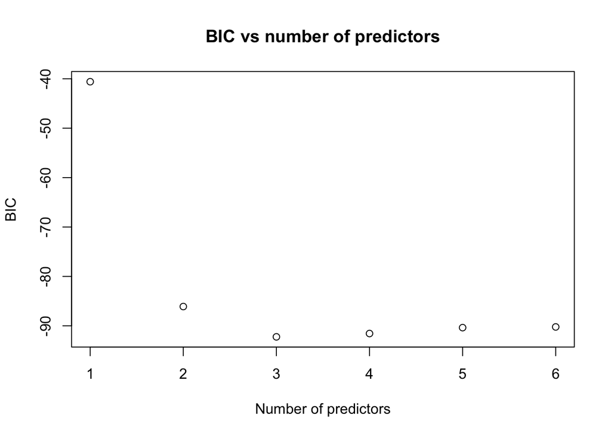

```r
plot(1:6, rs$bic, ylab="BIC", xlab="Number of predictors", main="BIC vs number of predictors") # We can see that suggestion of choosing 3 predictors
```

```r
mdlBIC <- lm(BP ~ Age+Weight+BSA, data=bloodData)

summary(mdlBIC) #The bigger has better fit for the data
```

```
##
## Call:
## lm(formula = BP ~ Age + Weight + BSA, data = bloodData)
##
## Residuals:
##      Min       1Q   Median       3Q      Max
## -0.75810 -0.24872  0.01925  0.29509  0.63030
##
## Coefficients:
##              Estimate Std. Error t value Pr(>|t|)
## (Intercept) -13.66725    2.64664  -5.164 9.42e-05 ***
## Age           0.70162    0.04396  15.961 3.00e-11 ***
## Weight        0.90582    0.04899  18.490 3.20e-12 ***
## BSA           4.62739    1.52107   3.042  0.00776 **
## ---
## Signif. codes:  0 '***' 0.001 '**' 0.01 '*' 0.05 '.' 0.1 ' ' 1
##
## Residual standard error: 0.437 on 16 degrees of freedom
## Multiple R-squared:  0.9945, Adjusted R-squared:  0.9935
## F-statistic: 971.9 on 3 and 16 DF,  p-value: < 2.2e-16
```